# Homework1

## Interpretation of the cluster centers

As we have previously discarded k-means as a clustering method, we will do an interpretation of the cluster centers using the PAM method.

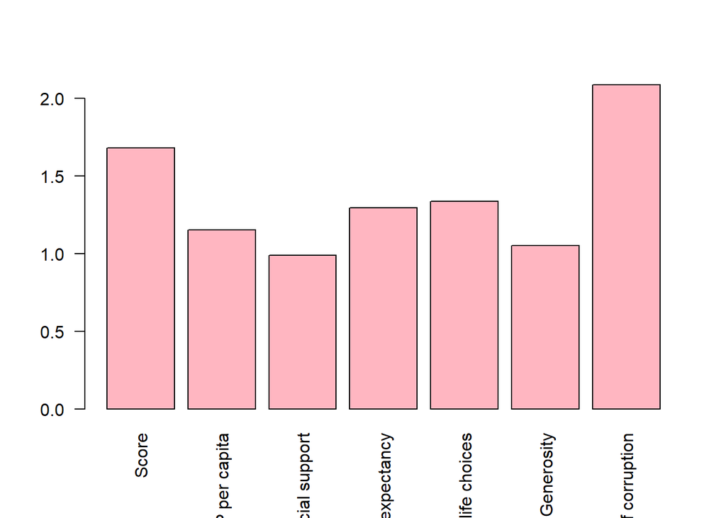

```r
fit = pam(scale(happiness_numeric), k=3)
centers = fit$medoids
barplot(centers[1,], las=2, col="lightpink")
```

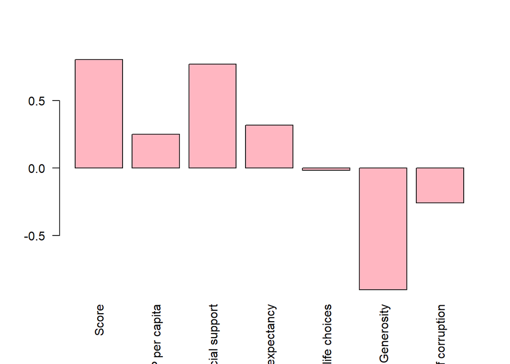

```r
barplot(centers[2,], las=2, col="lightpink")
```

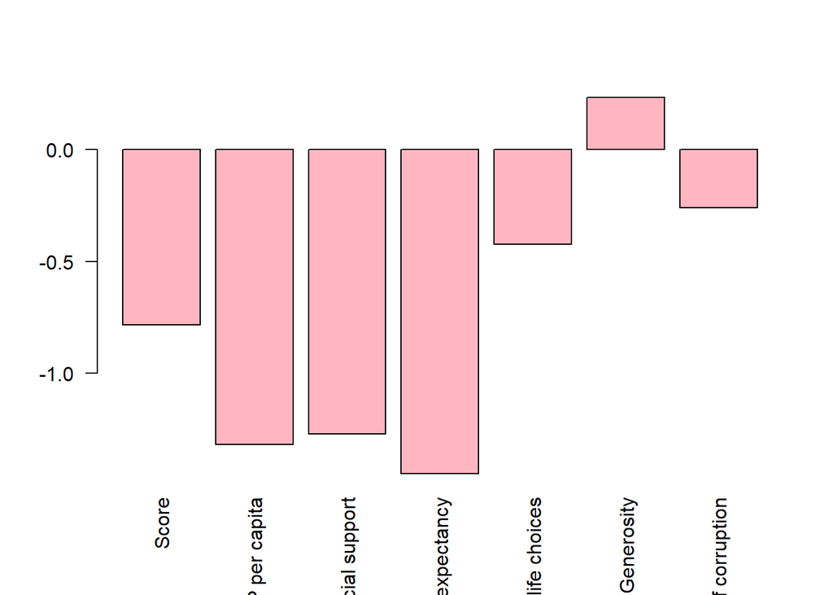

```r
barplot(centers[3,], las=2, col="lightpink")
```

There are two clusters with countries with good scores and a cluster with bad scores. Nonetheless, while the first cluster has high rankings on all the metrics, the second cluster has very low and even negative rankings on metrics such as life choices, generosity and corruption while having lower but still positive scores. In fact, the second cluster has a much lower generosity metric than the third cluster, which has a negative score metric.

## Similarities between the different methods

How similar are the clusters with EM compared to the clusters obtained using PAM clustering?

```r
adjustedRandIndex(res.Mclust$classification, fit.pam$clustering)
```

```
## [1] 0.6830863
```

The EM and PAM clusters are somewhat similar, confirming what we have already seen with the maps.

# Conclusion

In conclusion, we have achieved what we had originally set out to do. Using a correlation matrix, principal component analysis, factor analysis and clustering we have identified the different relations between the score and the rest of the variables, managing to lower the dimensions that we have to take into account. Within the variables it is clear, for example, that a country’s overall happiness is impacted far less by its generosity and perceptions of corruption than by its GDP per capita.

Furthermore, our factor analysis could be used in the future to predict a country’s happiness as a function of the other six variables (GDP per capita, social support, healthy life expectancy, freedom to make choices, generosity and perceptions of corruption).